# R Basic Grammar

Variable, Condition, Loop and Debug

Humoon

2022-03-22

```r
library(lobstr)
```

*R base cheatsheet.pdf*

[figure not shown]

## R 变量

### 查看变量属性

| 函数 | 说明 |
| --- | --- |
| `object.size(x)` | 对象所占内存空间的大小 (bytes) |
| `length(x)` | 对象的 size |
| `is.*(x)` | 判断数据类型。判断向量最好用 `is.atomic()` 而非 `is.vector()` |
| `as.*(x)` | 强制转换数据类型 |
| `typeof(x)/mode(x)` | 查看对象的数据类型。 若对象为homogeneous data types，则返回元素的数据类型，如 integer, double, character, logical；若为异质性的列表或数据框，则返回 list |
| `class(x)` | 查看对象所属的类 |
| `str(x)` | 对象的class、结构和概要信息 |
| `tibble::glimpse()` | tibble 版`str()`，不显示class，只显示数据 |
| `dim(x)` | 返回对象的维度，只适用于矩阵和数据框 |
| `summary(x)` | 按列汇总对象的基本信息。对于因子，汇总取每一个水平的行数；对于数值向量，返回重要的分位数；对于其他类型的列，则显示列的长度、类型和模式。 |
| `head(x, n)` | 列出对象的前n个元素，默认n为6 |
| `tail(x, n)` | 列出对象的后n个元素 |

```r
df = data.table(id = 1:10, lower = letters[1:10])

typeof(df)
```

```
#> [1] "list"
```

```r
class(df)
```

```
#> [1] "data.table" "data.frame"
```

```r
str(df)
```

```
#> Classes 'data.table' and 'data.frame':   10 obs. of  2 variables:
#>  $ id   : int  1 2 3 4 5 6 7 8 9 10
#>  $ lower: chr  "a" "b" "c" "d" ...
#>  - attr(*, ".internal.selfref")=<externalptr>
```

```r
glimpse(df)
```

```
#> Rows: 10
#> Columns: 2
#> $ id    <int> 1, 2, 3, 4, 5, 6, 7, 8, 9, 10
#> $ lower <chr> "a", "b", "c", "d", "e", "f", "g", "h", "i", "j"
```

```r
df %>% summary()
```

```
#>        id           lower
#>  Min.   : 1.00   Length:10
#>  1st Qu.: 3.25   Class :character
#>  Median : 5.50   Mode  :character
#>  Mean   : 5.50
#>  3rd Qu.: 7.75
#>  Max.   :10.00
```

### 变量名

#### 指针

对象的变量名是一个常量指针，指向一个对象所在的地址。

```r
x <- c(1, 2, 3)
y <- x
# x, y 为指向同一个向量的指针
obj_addr(x)
```

```
#> [1] "0x260206e8"
```

```r
obj_addr(y)
```

```
#> [1] "0x260206e8"
```

#### 不规则变量名

要用反引号括起来

```r
c %>% class() # c是一个内置函数，所以一般变量不能以'c命名
```

```
#> [1] "function"
```

```r
c
```

```
#> function (...)  .Primitive("c")
```

```r
`x+1` <- function(n) n + 1
`x+1`
```

```
#> function(n) n + 1
```

```r
`x+1`(3)
```

```
#> [1] 4
```

### 修改时复制 copy-on-modify

R 中的对象一般不许被修改（就像 JS 中的`const`常量），这对数据安全有好处。

赋值时 R 大量使用了拷贝机制，这是 R 速度慢的一个主要原因。如显示循环，每次迭代都会复制对象。

#### 会复制对象的情形

##### 数字向量

1. 有多个指针指向同一个对象，且通过其中一个指针修改该对象时，会生成该对象的一个副本（一个新对象）。修改作用在这个副本上，然后使被修改的指针指向这个副本。

   ```r
   x <- c(1, 2, 3)
   # tracemen()跟踪x指针指向的对象，每当这个对象被复制，tracemem()都会打印一条说明
   cat(tracemem(x), "\n")
   ```

   ```
   #> <00000000267C1FC8>
   ```

   ```r
   y <- x
   y[3] <- 4L # 发生拷贝
   ```

   ```
   #> tracemem[0x00000000267c1fc8 -> 0x00000000239b4e30]: eval eval eval_with_user_handlers withVisible withCallingHandlers handle timing_fn evaluate_call <Anonymous> evaluate in_dir eng_r block_exec call_block process_group.block process_group withCallingHandlers process_file <Anonymous> <Anonymous>
   ```

   ```r
   obj_addr(x)
   ```

   ```
   #> [1] "0x267c1fc8"
   ```

   ```r
   obj_addr(y)
   ```

   ```
   #> [1] "0x239b4e30"
   ```

   ```r
   untracemem(x) # 关闭跟踪
   ```

2. 对象作为参数传递给函数，并在函数内部修改对象时，也会创建对象的副本
   1. 函数外部的变量名仍指向未被修改的原对象
   2. 但**如果使用运算符 `<<-`，就可以修改函数外部的变量（如一些随着迭代一轮轮更新的统计变量）**。某些情况下，这个功能非常重要，可以**通过函数修改外部变量**。

   ```r
   modify_first <- function(x) {
     x[1] <- 0
     x
   }
   v1 <- c(1, 2, 3)
   cat(tracemem(v1), "\n")
   ```

   ```
   #> <0000000023C1BC70>
   ```

   ```r
   modify_first(v1)
   ```

   ```
   #> tracemem[0x0000000023c1bc70 -> 0x0000000022bfb7e0]: modify_first eval eval eval_with_user_handlers withVisible withCallingHandlers handle timing_fn evaluate_call <Anonymous> evaluate in_dir eng_r block_exec call_block process_group.block process_group withCallingHandlers process_file <Anonymous> …
   #> [1] 0 2 3
   ```

   ```r
   v1 # 外部的 v1 未被修改
   ```

   ```
   #> [1] 1 2 3
   ```

   ```r
   x <- 0
   cat(tracemem(x), "\n")
   ```

   ```
   #> <0000000024612AC8>
   ```

   ```r
   modify_x <- function(value) {
     x <<- value
   }
   modify_x(3)
   x # 外部的 x 被修改了
   ```

   ```
   #> [1] 3
   ```

##### 列表

为了节省空间，列表储存的不是对象，而是指针。修改列表时，只有变化的元素会复制。

```r
a <- 1:10
b <- list(a, a)
c <- list(b, a, 1:10)
ref(a, b, c)
```

```
#> [1:0x247db0a8] <int>
#>
#> o [2:0x2641d1d0] <list>
#> +-[1:0x247db0a8]
#> \-[1:0x247db0a8]
#>
#> o [3:0x22ccf840] <list>
#> +-[2:0x2641d1d0]
#> +-[1:0x247db0a8]
#> \-[4:0x24870d10] <int>
```

```r
l1 <- list(1, 2, 3)
l2 <- l1
# 拷贝机制启动，但拷贝的是指针，而不是 value，这是浅拷贝
l2[[3]] <- 4
lobstr::ref(l1, l2)
```

```
#> o [1:0x22c02450] <list>
#> +-[2:0x255b0de0] <dbl>
#> +-[3:0x255b0da8] <dbl>
#> \-[4:0x255b0d70] <dbl>
#>
#> o [5:0x26009fd0] <list>
#> +-[2:0x255b0de0]
#> +-[3:0x255b0da8]
#> \-[6:0x255b0c90] <dbl>
```

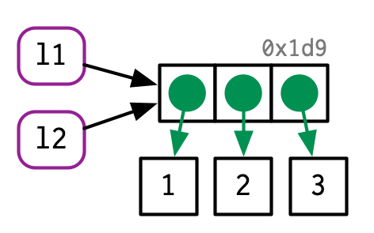

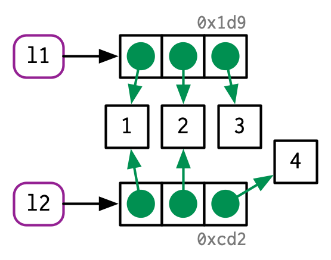

##### 数据框

数据框本质上是一个列表，储存的都是指向列向量的指针。

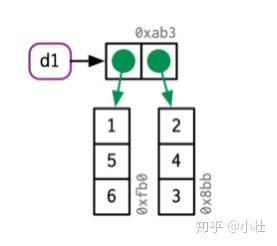

```r
d1 <- data.frame(x = c(1, 5, 6), y = c(2, 4, 3))
d2 <- d1
d3 <- d1
ref(d1, d2)
```

```
#> o [1:0x27a51218] <df[,2]>
#> +-x = [2:0x27a55688] <dbl>
#> \-y = [3:0x27a55638] <dbl>
#>
#> [1:0x27a51218]
```

```r
ref(d1, d3)
```

```
#> o [1:0x27a51218] <df[,2]>
#> +-x = [2:0x27a55688] <dbl>
#> \-y = [3:0x27a55638] <dbl>
#>
#> [1:0x27a51218]
```

```r
# 修改列，该列复制；其他列扔指向原对象
d2[, 2] <- d2[, 2] * 2
ref(d1, d2)
```

```
#> o [1:0x27a51218] <df[,2]>
#> +-x = [2:0x27a55688] <dbl>
#> \-y = [3:0x27a55638] <dbl>
#>
#> o [4:0x27aecb48] <df[,2]>
#> +-x = [2:0x27a55688]
#> \-y = [5:0x27aeecc8] <dbl>
```

```r
# 修改行，必须复制每一列
d3[1, ] <- d3[1, ] * 3
ref(d1, d3)
```

```
#> o [1:0x27a51218] <df[,2]>
#> +-x = [2:0x27a55688] <dbl>
#> \-y = [3:0x27a55638] <dbl>
#>
#> o [4:0x27b7db38] <df[,2]>
#> +-x = [5:0x27b8b058] <dbl>
#> \-y = [6:0x27b8b008] <dbl>
```

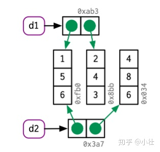

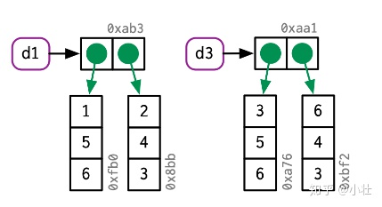

##### 字符向量

也是指针的向量。每个指针指向一个字符串，这个字符串位于全局字符串池中。

```r
x <- c("a", "a", "abc", "d")
ref(x, character = TRUE)
```

```
#> o [1:0x23fd8e98] <chr>
#> +-[2:0x140f9d70] <string: "a">
#> +-[2:0x140f9d70]
#> +-[3:0x2164ca10] <string: "abc">
#> \-[4:0x142f3cd8] <string: "d">
```

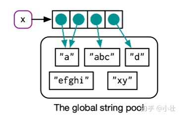

#### 不会复制对象的情形

##### 唯一指针

只有一个指针指向对象时，修改对象不会发生复制。

(Rstudio 中与 Console 中不同，Rstudio 中仍要复制)

```r
z <- c(1, 2, 3, 4, 5)
cat(tracemem(z), "\n")
```

```
#> <0000000025951860>
```

```r
z[3] <- 4L
```

```
#> tracemem[0x0000000025951860 -> 0x0000000025aa0c10]: eval eval eval_with_user_handlers withVisible withCallingHandlers handle timing_fn evaluate_call <Anonymous> evaluate in_dir eng_r block_exec call_block process_group.block process_group withCallingHandlers process_file <Anonymous> <Anonymous>
```

```r
z
```

```
#> [1] 1 2 4 4 5
```

```r
obj_addr(z)
```

```
#> [1] "0x25aa0c10"
```

```r
untracemem(z) # 关闭跟踪
```

但是，R 对指针数量的判断不够智能。如两个指针指向一个对象，其中一个被删除后，R 却不知道，仍然以为有两个指针。因此会产生很多不必要的对象拷贝。

```r
x <- data.frame(matrix(runif(5 * 1e4), ncol = 5))
cat(tracemem(x), "\n")
```

```
#> <00000000260242A8>
```

```r
medians <- vapply(x, median, numeric(1))
```

```
#> tracemem[0x00000000260242a8 -> 0x0000000026042648]: as.list.data.frame as.list vapply eval eval eval_with_user_handlers withVisible withCallingHandlers handle timing_fn evaluate_call <Anonymous> evaluate in_dir eng_r block_exec call_block process_group.block process_group withCallingHandlers proc…
```

```r
for (i in 1:5) {
  x[[i]] <- x[[i]] - medians[[i]]
}
```

[output not shown]

##### 环境对象总是被就地修改

## 条件语句

### `if...else if...else...`

```r
if (condition1) {

} else if (condition2) {
  # else if中间有空格，跟 JavaScript 一样
} else {

}
```

### `ifelse()`

`if...else` 的 condition 不能是向量，将自动忽略条件向量中第一个以后的元素。有时，要用`any(bool vector)`和`all(bool vector)`将布尔向量转换为一个bool值，再配合`if`使用。

而三元选择符`ifelse(cond, statement1, statement2)`可以接收三个向量，按各自分量执行向量化操作

> 对应 JS 中的 `condition? Statement1: statement2;`

### `switch(statement, list)`

list 是一组键值对，statement 是一个键，返回 list 中与该键对应的值。

```r
result1 = switch('fruit',
                 meat = "chicken",
                 fruit = "apple",
                 vegetable = "cucumber",
                 'soup')
result1
# [1] "apple"

result2 = switch('final',
                 meat = "chicken",
                 fruit = "apple",
                 vegetable = "cucumber",
                 'soup')
result2 # 都不匹配时，返回无key的值
# [1] "soup"
```

## 循环语句

### `repeat{}`

必须手动指定 break 条件，否则无限循环。这在创建交互式 app 时很有用。

### `for( iterator in sequence) {}`

#### 预先分配空间：提高传统 for 循环的效率

R 中如果对对象的 size 做了改动（如添加一个元素），要把整个数据结构都重新拷贝一份，这非常慢。如果在每次循环中都有这种语句，时间复杂度会是$\mathrm{O}\left(\mathrm{n}^{2}\right)$级的。

所以最好在开始循环前，预先声明一个向量，为输出结果分配足够的空间，这对循环效率非常重要。预先分配的空间往往是一个list，在循环结束后需要打散并重组为我们需要的对象：对于向量用`unlist()`，数据框用`dplyr::bind_rows()`

这其实有点像 JS 里面的:

```javascript
const arr = [];
for (let i = 0; i < 6; i++) {
  arr.push(i ^ 2 % 11);
}
console.log(arr);
```

例：

```r
df <- tibble(
  a = rnorm(10),
  b = rnorm(10),
  c = rnorm(10),
  d = rnorm(10)
)

# 要求df各列的中位数，先为输出分配空间，长度为ncol(df)的向量
output <-  double(ncol(df))
for (i in 1:ncol(df)) {
  output[[i]] <- median(df[[i]])
}
output
```

```
#> [1] -0.26629871  0.08006262 -0.16643811  0.29386703
```

## Debug

`stop(string)` 终止程序并报错：“Error: string”